# Stat400 Project 2

Example code:

```r
#We start by code to simulate flipping a fair coin 100 times. We use the fact that we can regard a bernoulli distribution as a binomial distribution with where the number of repetitions n = 1. The number 1 indicates heads.
set.seed(1)
coin_flips <- rbinom(100, 1, .5)
coin_flips
```

```
##   [1] 0 0 1 1 0 1 1 1 1 0 0 0 1 0 1 0 1 1 0 1 1 0 1 0 0 0 0 0 1 0 0 1 0 0 1 1 1
##  [38] 0 1 0 1 1 1 1 1 1 0 0 1 1 0 1 0 0 0 0 0 1 1 0 1 0 0 0 1 0 0 1 0 1 0 1 0 0
##  [75] 0 1 1 0 1 1 0 1 0 0 1 0 1 0 0 0 0 0 1 1 1 1 0 0 1 1
```

```r
Data <- data.frame(toss_number = (1:length(coin_flips)) , toss_result = coin_flips)
head(Data, 5)
```

|  | toss_number | toss_result |
| --- | --- | --- |
| 1 | 1 | 0 |
| 2 | 2 | 0 |
| 3 | 3 | 1 |
| 4 | 4 | 1 |
| 5 | 5 | 0 |

```r
frequencies <- function(vec){
 # get the length of the vector we are using in the calclations.
 len_vec <- length(vec)

 # Create vector to store evolving averages
 avg <- 1:len_vec

 # loop through to compute the averages. We compute the averages by counting the number of
 for(i in 1:len_vec){
     avg[i] <- length(which(vec[1:i]==1))/i
 }
  return(avg)
}

 # We add a new column to the dataframe that contains the averages
 freq <- frequencies(coin_flips)
 Data$avgs <- freq
 head(Data, 5)
```

|  | toss_number | toss_result | avgs |
| --- | --- | --- | --- |
| 1 | 1 | 0 | 0.0000000 |
| 2 | 2 | 0 | 0.0000000 |
| 3 | 3 | 1 | 0.3333333 |
| 4 | 4 | 1 | 0.5000000 |
| 5 | 5 | 0 | 0.4000000 |

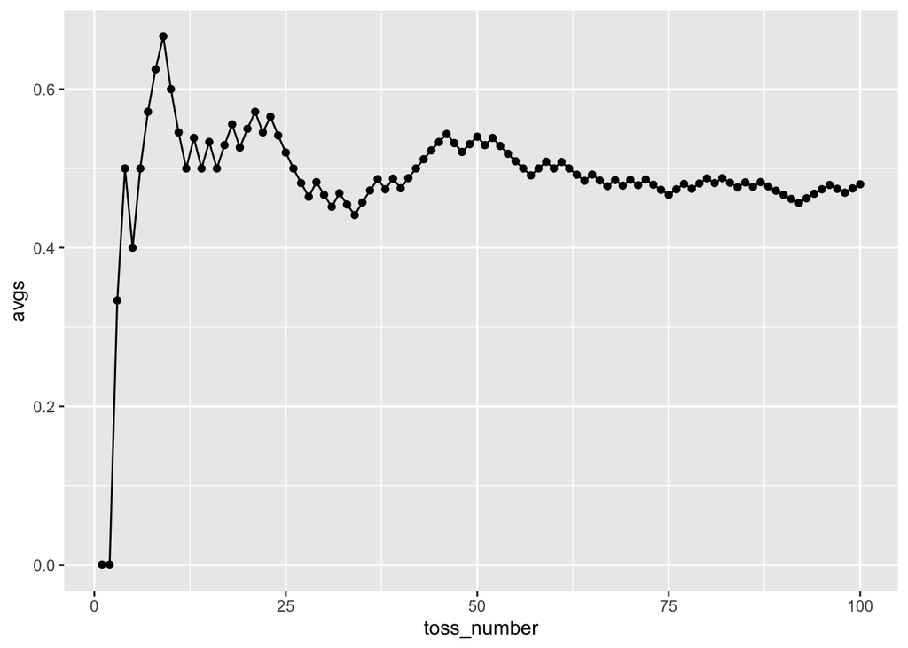

```r
library(ggplot2)

ggplot(data=Data, aes(x=toss_number, y=avgs, group=1)) +
  geom_line()+
  geom_point()
```

```r
#Set seed for reproducibility
  set.seed(1)

#simulate sample
  sum <- runif(10000, min = 0, max = 1)

#compute the sample average
  mean(sum)
```

```
## [1] 0.500168
```

```r
estimate_pi <- function(seed = 1, iterations = 100000000) {
  #setting seed for reproducibility
  set.seed(seed)

  #generating the points

  x <- runif(n = iterations, min = 0, max = 1)

  #Computing an approximation for pi /4

  val_of_g = sqrt(1-x^2)

  pi_over_four = mean(val_of_g)

  #estimating pi using formula pi = 4*the mean

  pi <- 4 * pi_over_four
  return(pi)

}
```

```r
estimate_pi()
```

```
## [1] 3.141566
```

```r
# load required libraries
library('tidyverse')
```

```r
# Function that mimics the lottery and graphs
lottery <- function(seed = 1, iterations = 15000) {

#Set seed for reproducibility
  set.seed(seed)

#generate n sets of ticket numbers where a ticket number is a set of three
#integers between 1 and 4 inclusive
  num1 <- floor(runif(n = iterations, min = 1, max = 4))
  num2 <- floor(runif(n = iterations, min = 1, max = 4))
  num3 <- floor(runif(n = iterations, min = 1, max = 4))

#Calculate sum of each ticket
  sum <- num1 + num2 + num3

#Create dataframe with ticket numbers in order to make easier to graph
  ticket <- 100*num1 + 10*num2 + num3
  ticket <- as.data.frame(ticket)

#Count occurrences of each ticket number
  df <- ticket %>%
    group_by(ticket) %>%
    summarise(counts = n())

#Graphs occurrences of each ticket number
    df$ticket <- as.factor(df$ticket)
    p <- ggplot(df, aes(x = ticket, y = counts)) +
      geom_bar(fill = "#0073C2FF", stat='identity') +
      theme_bw()
    print(p)

  return(list(df, table(sum)))
}
```

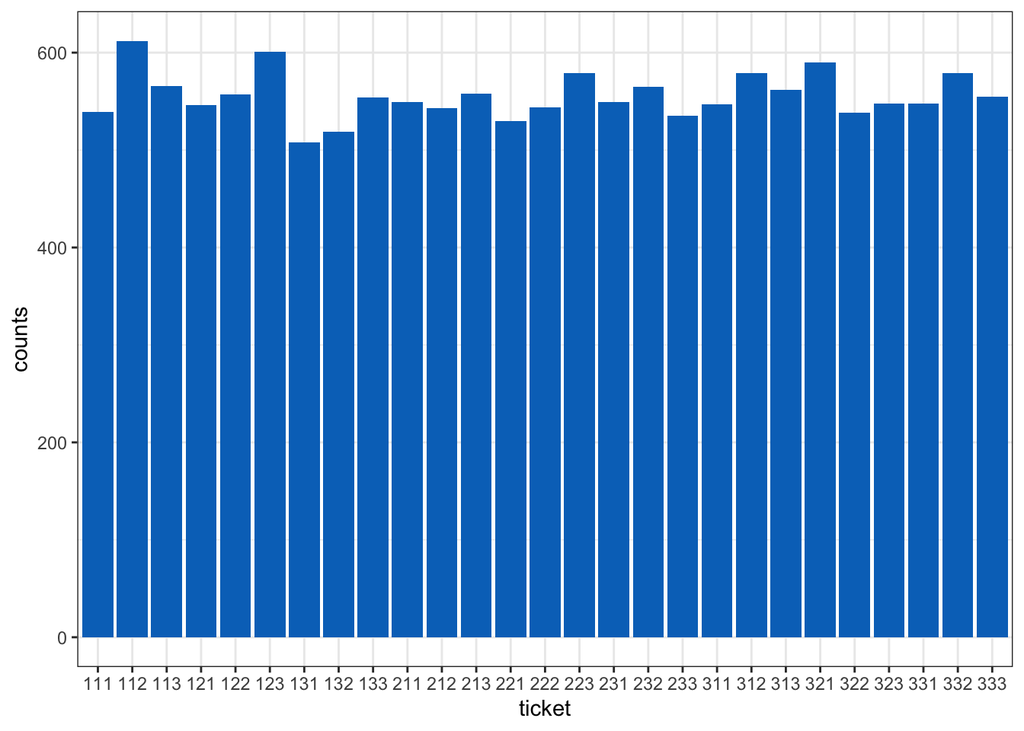

```
## [[1]]
## # A tibble: 27 × 2
##    ticket counts
##    <fct>   <int>
##  1 111       539
##  2 112       612
##  3 113       566
##  4 121       546
##  5 122       557
##  6 123       601
##  7 131       508
##  8 132       519
##  9 133       554
## 10 211       549
## # ℹ 17 more rows
##
## [[2]]
## sum
##    3    4    5    6    7    8    9
##  539 1707 3251 3940 3346 1662  555
```

```r
lottery()
```

### Project Starts Here

Note my UID is 119718025 so I set all seeds to 25

1.) Consider an experiment where you toss a a fair coin 15 times. Let X be the number of heads that you obtain. Note that X~Bin(15, 1/2).

1a.) Compute P(X=7) (using the formulas associated with the binomial distributions. R can compute the theoretical value as well if you choose to go that route)

```r
#using P(X=k) = (n choose k)*(p^k)*(1-p)^(n-k) for X~Bin(n,p), we can calculate P(X=7) as follows:
prob_xis7 <- choose(15, 7)*(0.5)^7*(1-0.5)^(15-7)
prob_xis7
```

```
## [1] 0.1963806
```

1b.) Plot the evolution of the relative frequency for X=7 based on 100,000 repetitions of the above.

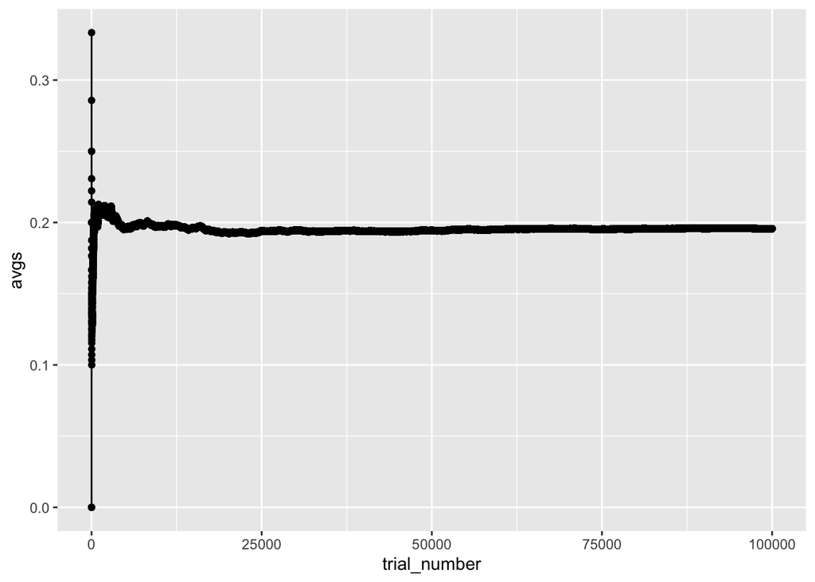

```r
set.seed(25)
seven_heads <- rbinom(100000, 1, prob_xis7)

Data <- data.frame(trial_number = (1:length(seven_heads)), trial_result = seven_heads)

frequencies <- function(vec) {
  len_vec <- length(vec)
  avg <- 1:len_vec
  for(i in 1:len_vec) {
    avg[i] <- length(which(vec[1:i]==1))/i
  }
  return(avg)
}
freq <- frequencies(seven_heads)
Data$avgs <- freq

library(ggplot2)
ggplot(data=Data, aes(x=trial_number, y=avgs, group=1)) +
  geom_line() +
  geom_point()
```

1c.) Explain how your observations match up with the frequentist interpretation of probability.

We can see that in the early trials, the relative frequency for X=7 deviates considerably from the true probability of getting 7 heads (~0.1963806), and jumps both above and below this value. However, as the number of trials increases, the relative frequency stabilizes and gets closer to this true probability. This matches up with the frequentist interpretation of probability, which states that as the number of trials increases, the relative frequency of getting a particular outcome gets closer to the true probability of getting that outcome.

1d.) Compute E(X) and the observed average of the repetitions.

```r
EofX <- 15*0.5 #using E(X) = np for X~Bin(n,p)
EofX
```

```
## [1] 7.5
```

```r
set.seed(25)
x <- rbinom(100000, 15, 0.5)
obs_avg <- sum(x)/100000 #observed average of repetitions
obs_avg
```

```
## [1] 7.49845
```

1e.) Do your observations match up with the law of large numbers?

The observed average of the repetitions, 7.49845, is very close to the expected value of X (E(X) = 7.5). This matches up with the law of large numbers, which states that for almost every large sample x1,…,xn obtained using the distribution of X, the sum from i=1 to n of xi/n is approximately equal to E(X). In simpler words, the larger the sample size of a sample taken from the distribution of a random variable X, the closer the sample mean is to E(X).

2.) Experimentally verify the law of large numbers for the standard normal distribution and an exponential distribution with λ=5.

```r
set.seed(25)
small_normal <- rnorm(10)
mean(small_normal)
```

```
## [1] -0.1743769
```

```r
large_normal <- rnorm(100000)
mean(large_normal)
```

```
## [1] 0.0009338873
```

```r
small_exp <- rexp(10, rate=5)
mean(small_exp)
```

```
## [1] 0.2189413
```

```r
large_exp <- rexp(100000, rate=5)
mean(large_exp)
```

```
## [1] 0.2003544
```

For X~Normal(0,1), E(X)=0. We can see that when the sample size is 10, the sample mean of -0.1743769 is somewhat, but not very, close to this E(X). However, when the sample size is 100000, the sample mean of 0.0009338873 is very close to this E(X). For X~Exp(5), E(X)=1/5=0.2. As with the normal distribution, we can see that for a sample of 10, the sample mean of 0.2189413 is only somewhat close to this E(X). However, for a sample of 100000, the sample mean of 0.2003544 is very close to this E(X). This verifies the law of large numbers for these distributions, which states that for a sufficiently large sample from the distribution of a random variable, the sample mean is approximately equal to the expected value of the random variable.

3.) (Simulating the lottery) Modify the above code to display the frequencies (or the relative frequencies) of the sums. Summarize your observations.

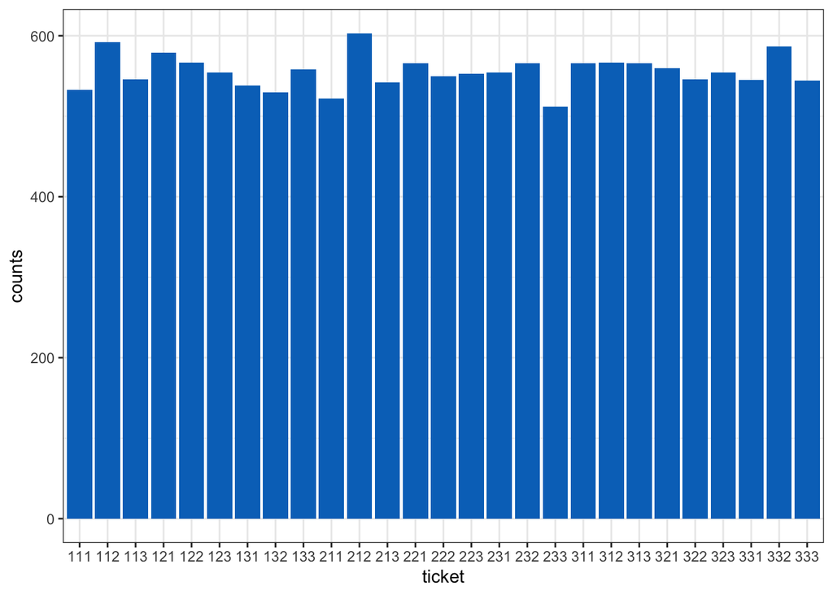

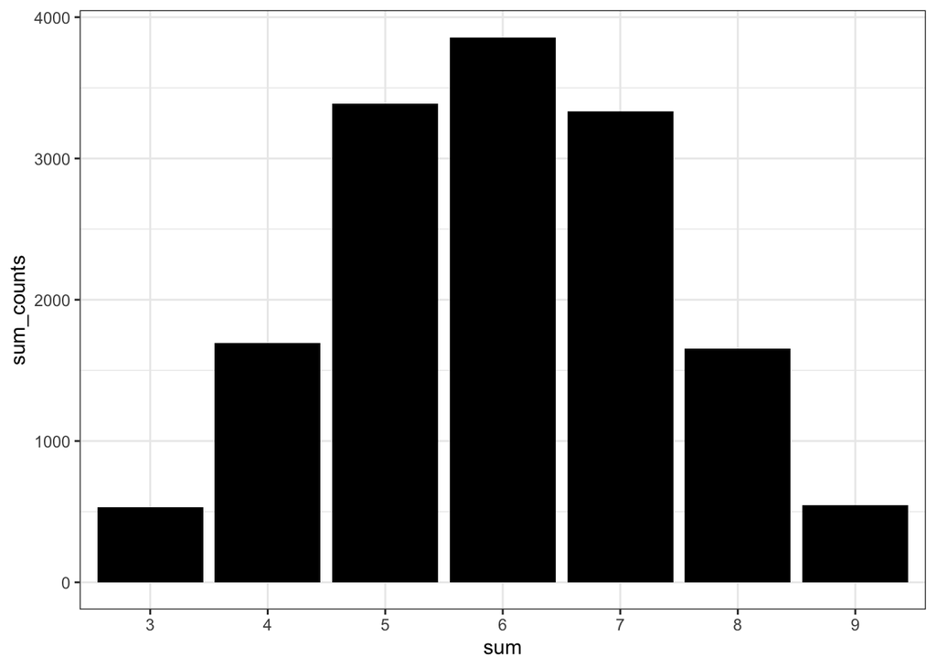

```
## [[1]]
## # A tibble: 27 × 2
##    ticket counts
##    <fct>   <int>
##  1 111       533
##  2 112       592
##  3 113       546
##  4 121       579
##  5 122       567
##  6 123       554
##  7 131       538
##  8 132       530
##  9 133       558
## 10 211       522
## # ℹ 17 more rows
##
## [[2]]
## sum
##    3    4    5    6    7    8    9
##  533 1693 3386 3857 3334 1653  544
```

```r
# load required libraries
library('tidyverse')

# Function that mimics the lottery and graphs
lottery <- function(seed = 25, iterations = 15000) {

#Set seed for reproducibility
  set.seed(seed)

#generate n sets of ticket numbers where a ticket number is a set of three
#integers between 1 and 4 inclusive
  num1 <- floor(runif(n = iterations, min = 1, max = 4))
  num2 <- floor(runif(n = iterations, min = 1, max = 4))
  num3 <- floor(runif(n = iterations, min = 1, max = 4))

#Calculate sum of each ticket
  sum <- num1 + num2 + num3

#Create dataframe with ticket numbers in order to make easier to graph
  ticket <- 100*num1 + 10*num2 + num3
  ticket <- as.data.frame(ticket)

#Count occurrences of each ticket number
  df <- ticket %>%
    group_by(ticket) %>%
    summarise(counts = n())

#Graphs occurrences of each ticket number
    df$ticket <- as.factor(df$ticket)
    p <- ggplot(df, aes(x = ticket, y = counts)) +
      geom_bar(fill = "#0073C2FF", stat='identity') +
      theme_bw()
    print(p)

#Count occurrences of each sum
    df2 <- data.frame(sum=sum) %>%
      group_by(sum) %>%
      summarise(sum_counts = n())

#Graph occurrences of each sum
    df2$sum <- as.factor(df2$sum)
    sums_plot <- ggplot(df2, aes(x = sum, y = sum_counts)) +
      geom_bar(fill = "#000000", stat='identity') +
      theme_bw()
    print(sums_plot)

    return(list(df, table(sum)))
}

lottery()
```

The distribution of the sums appears bell-shaped with a center around 6. The distribution is symmetrical with a peak at 6, and as we move farther from this center in either direction the frequency of the sum decreases. It’s notable that the distribution is centered around the expected value of the sum, 3[1(1/3)+2(1/3)+3(1/3)]=6. The distribution suggests that 6 is the most common sum, followed by 5 and 7, then 4 and 8, then 3 and 9. Intuitively, this makes sense, as there are more tickets whose digits sum to 6 (123, 132, 213, 222, 231, 312, 321 –> 7 unique tickets) than any other number. It also makes sense that there are approximately 7 times as many sums of 6 as there are sums of 3 (3857/533 ≈ 7), since there are 7 unique tickets whose digits sum to 6 and only 1 unique ticket whose digits sum to 3 (111), and each ticket has an equal likelihood of being selected.

4.) (Monte Carlo Methods):

4a.) Estimate the value of π by considering X~U[-1,1] and g(x) = √(1-x^2). You will need to factor in fX(x) = 1/2 for x ⍷ [-1,1]; 0 otherwise when you use the estimate. You should use an n that is at least 1,000,000.

```r
pi_estimation <- function(seed = 25, iterations = 100000000) {
  #setting seed for reproducibility
  set.seed(seed)

  #generating the points
  x <- runif(n = iterations, min = -1, max = 1)

  #computing an approximation for pi/4
  val_of_g = sqrt(1-x^2)
  pi_over_four = mean(val_of_g)

  #estimating pi using formula pi = 4*the mean
  pi <- 4 * pi_over_four
  return(pi)
}

pi_estimation()
```

```
## [1] 3.141601
```

4b.) Estimate the value of the integral from 0 to 2 of √(1 + t^2 + t^4)dt using a similar approach to (a)

```r
estimate_integral <- function(seed = 25, iterations = 100000000) {
  set.seed(seed)
  t <- runif(n = iterations, min = 0, max = 2)
  val_of_g = sqrt(1+t^2+t^4)

  #computing an approximation for half of the integral, since the full integral is evaluated from 0 to 2
  half_estimate <- mean(val_of_g)

  #estimating the full value of the integral by multiplying the mean by the length of the interval, 2
  full_estimate <- 2 * half_estimate
  return(full_estimate)
}

estimate_integral()
```

```
## [1] 4.194315
```

5.) Simulate 10000 repetitions each for X~Bin(21, 3/5) and Y~Bin(19, 3/5). Draw a relative frequency histogram. Does the outcome seem to support X+Y ~ Bin(40, 3/5)? Discuss your answer.

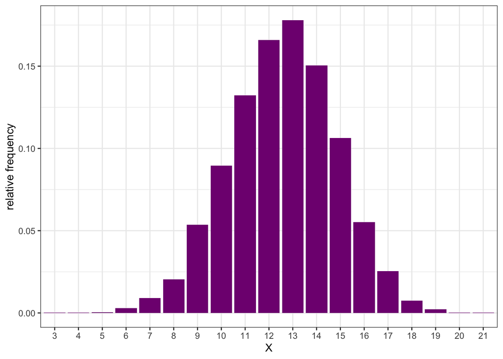

```r
set.seed(25)
X <- rbinom(10000, 21, 3/5)
df_X <- data.frame(X=X) %>%
    group_by(X) %>%
    summarise(X_counts = n())
df_X$X <- as.factor(df_X$X)
    X_plot <- ggplot(df_X, aes(x = X, y = X_counts/10000)) +
      geom_bar(fill = "#800080", stat='identity') +
      labs(y = 'relative frequency') +
      theme_bw()

Y <- rbinom(10000, 19, 3/5)
df_Y <- data.frame(Y=Y) %>%
    group_by(Y) %>%
    summarise(Y_counts = n())
df_Y$Y <- as.factor(df_Y$Y)
    Y_plot <- ggplot(df_Y, aes(x = Y, y = Y_counts/10000)) +
      geom_bar(fill = "#008000", stat='identity') +
      labs(y = 'relative frequency') +
      theme_bw()

df_XplusY <- data.frame(XplusY=(X+Y)) %>%
    group_by(XplusY) %>%
    summarise(XplusY_counts = n())
    XplusY_plot <- ggplot(df_XplusY, aes(x = XplusY, y = XplusY_counts/10000)) +
      geom_bar(fill = "#808000", stat='identity') +
      labs(y = 'relative frequency') +
      xlim(7,39) +
      theme_bw()

Z <- rbinom(100000000, 40, 3/5)
df_Z <- data.frame(Z=Z) %>%
    group_by(Z) %>%
    summarise(Z_counts = n())
df_Z$Z <- as.factor(df_Z$Z)
    Z_plot <- ggplot(df_Z, aes(x = Z, y = Z_counts/100000000)) +
      geom_bar(fill = "#000080", stat='identity') +
      labs(y = 'relative frequency') +
      theme_bw()

print(X_plot)
```

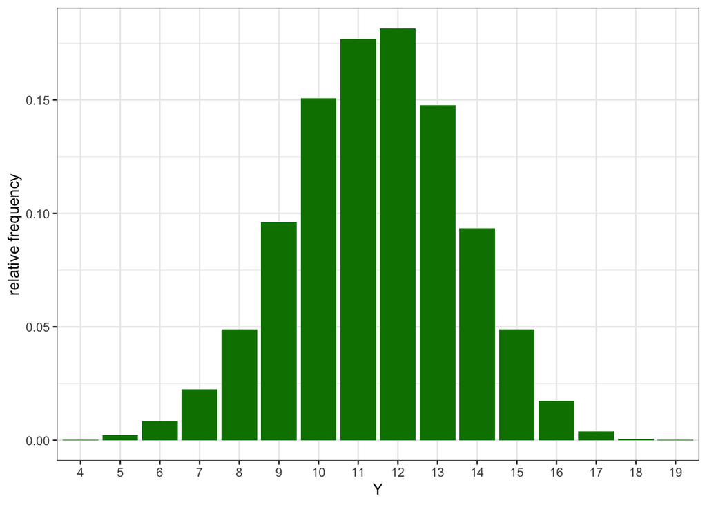

```r
print(Y_plot)
```

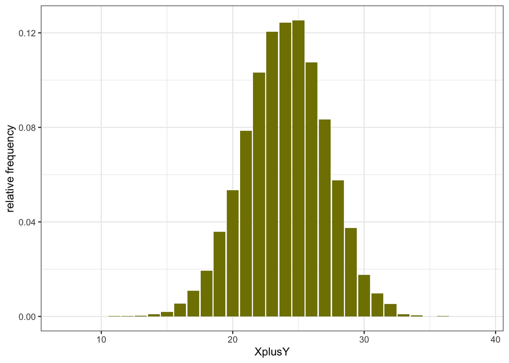

```r
print(XplusY_plot)
```

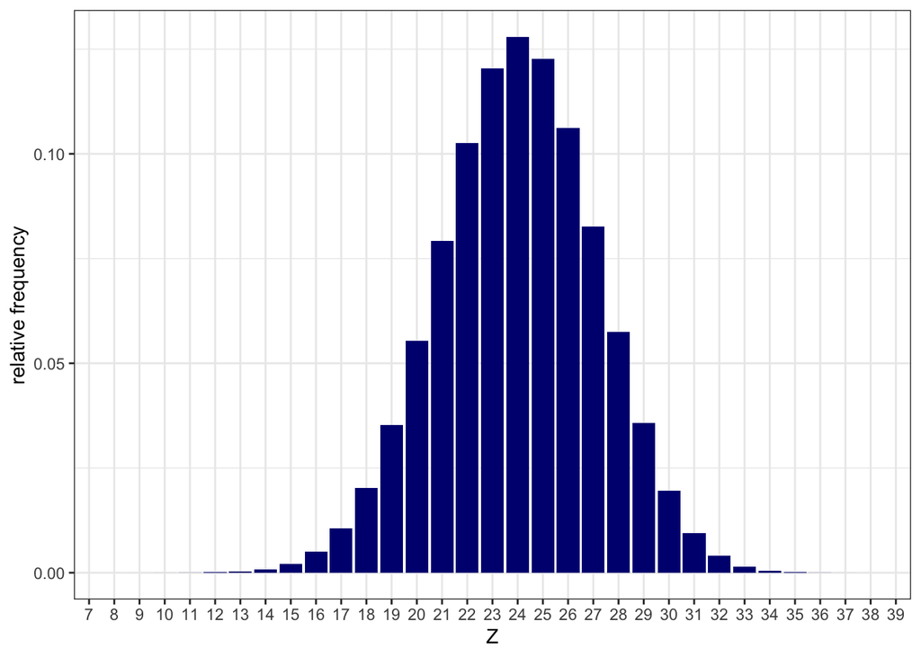

```r
print(Z_plot)
```

This outcome does seem to support that X+Y ~ Bin(40, 3/5). The third histogram shows the distribution of 10000 trials of X+Y, where X~Bin(21, 3/5) and Y~Bin(19, 3/5). The fourth histogram shows the distribution of 100000000 trials of Z, where Z~Bin(40, 3/5). Since the number of trials for Z is so large, we can say that the distribution of these 100000000 trials is very close to the true distribution of a binomial random variable with parameters n=40, p=3/5. This distribution also appears very similar to the distribution of X+Y in the third histogram: both distributions are centered around 24 with a very similar bell shape. The strong similarity between the distributions seems to support the statement X+Y ~ Bin(40, 3/5), although we cannot say this with absolute certainty just based on the similarity between distributions.